# Dudek_Gabriela_6_projekt1

Dudek_Gabriela

2024-11-27

## Sekcja 1

```r
library(sf) #biblioteka do obsługi danych przestrzennych
#install.packages("dbscan")
library("dbscan")
library(htmltools)
shp_sciezka <- st_read("D:\\adp\\adp_projekt\\zestaw6_XYTableToPoi_Project.shp") #dane z arcgis
print(shp_sciezka)
```

```
## Simple feature collection with 2000 features and 4 fields
## Geometry type: POINT
## Dimension:     XY
## Bounding box:  xmin: 7415455 ymin: 5539416 xmax: 7441359 ymax: 5553558
## Projected CRS: ETRS_1989_Poland_CS2000_Zone_7
## First 10 features:
##        Long      Lat POINT_X POINT_Y                geometry
## 1  19.92452 50.04527 7422972 5546010 POINT (7423106 5546021)
## 2  19.93998 50.06071 7424104 5547711 POINT (7424255 5547814)
## 3  19.90702 50.07866 7421773 5549741 POINT (7421740 5549851)
## 4  19.92570 50.03744 7423044 5545138 POINT (7423044 5545138)
## 5  20.05681 50.09096 7432511 5550963 POINT (7432509 5550967)
## 6  19.93112 50.06180 7423471 5547841 POINT (7423480 5547913)
## 7  20.00901 50.01499 7428978 5542559 POINT (7428978 5542559)
## 8  19.93842 50.05934 7423990 5547560 POINT (7423991 5547501)
## 9  19.95776 50.08907 7425420 5550848 POINT (7425470 5550652)
## 10 19.93974 50.05906 7424083 5547528 POINT (7423991 5547501)
```

```r
osiedla_sciezka <- st_read("D:\\adp\\osiedla.shp") #osiedla
```

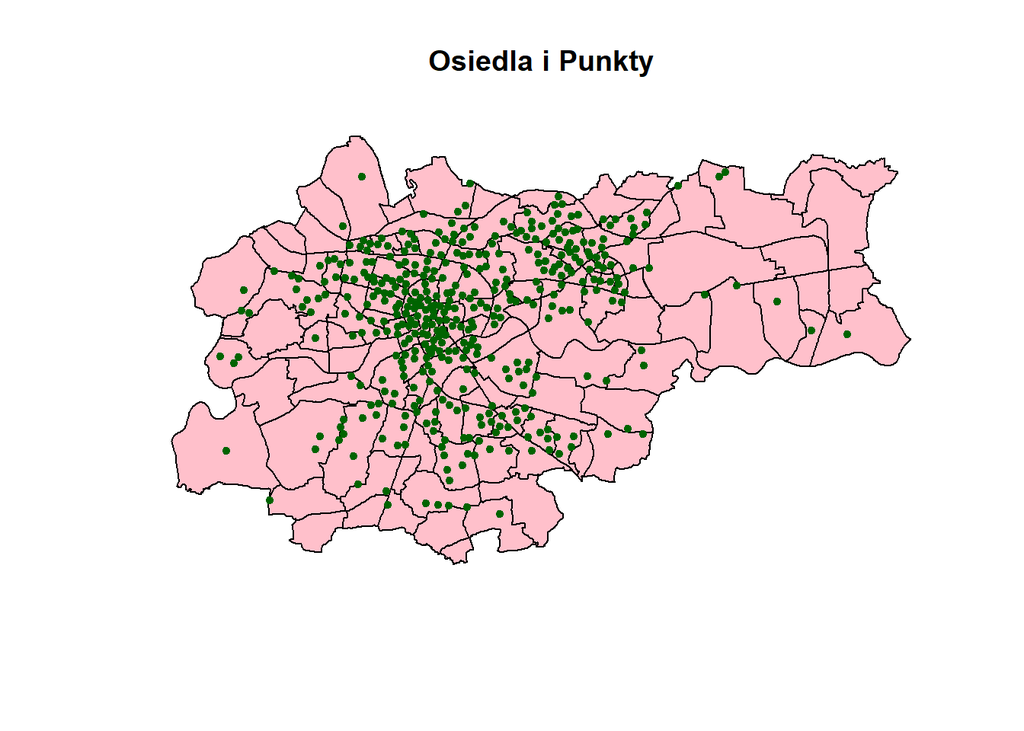

```r
#wizualizacja osiedli
plot(st_geometry(osiedla_sciezka), col = "pink", border = "black", main = "Osiedla i Punkty")

#naniesienie punktow na mapę osiedli
plot(st_geometry(shp_sciezka), col = "darkgreen", pch = 20, add = TRUE)
```

```r
#eps to maksymalna odleglosc miedzy dwoma punktami, ktora pozwala uznac je za sasiadow
#minPts - minimalna liczba punktow wymagana do utworzenia gęstego regionu (klastra)

#ramka danych jest nam potrzebna do dbscan
ramka_danych <- st_coordinates(shp_sciezka)
head(ramka_danych)
```

```
##            X       Y
## [1,] 7423106 5546021
## [2,] 7424255 5547814
## [3,] 7421740 5549851
## [4,] 7423044 5545138
## [5,] 7432509 5550967
## [6,] 7423480 5547913
```

# Przykłady z DBSCAN

## Przykład 1

```r
dbscan_dane <- dbscan(ramka_danych, eps= 300, minPts= 5)

#wyniki klasteryzacji dodane do danych punktowych
shp_sciezka$cluster <- as.factor(dbscan_dane$cluster)

#usuniecie szumów
shp_sciezka_filtered <- shp_sciezka[shp_sciezka$cluster != "0", ]

#print(shp_sciezka$cluster)
print(table(shp_sciezka_filtered$cluster))
```

```
##
##   0   1   2   3   4   5   6   7   8   9  10  11  12  13  14  15  16  17  18  19
##   0  16 412   8  33 173  16  50  12   5   6   8  25  14  17   6   6   7   8   6
##  20  21  22  23  24  25  26  27  28  29  30  31  32  33  34  35  36  37  38  39
##  47   6   5  16   5  58   7   5  11   7  18  55  31  24  13   5  14   8  20  11
##  40  41  42  43  44  45  46  47  48  49  50  51  52  53  54  55  56  57  58  59
##  11   9   9   6   8  13   7  13   6   5   8  13   5   5   8  13   5   6   6  19
##  60  61  62  63  64  65  66  67  68  69  70  71  72  73  74  75  76  77  78  79
##  14   5  19   7   5   6   5  10   6   9   9   6   6   6   5   6  10   6  19   7
##  80  81  82  83  84  85  86  87  88  89  90  91  92
##   6   5   6   6   8   5   5   6   5   5   6   5   5
```

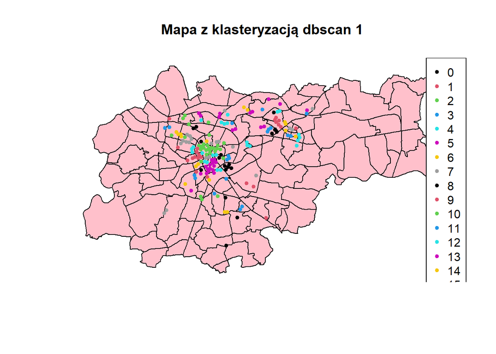

```r
#wizualizacja z klasteryzacją
plot(st_geometry(osiedla_sciezka), col = "pink", border = "black", main = "Mapa z klasteryzacją dbscan 1")
plot(st_geometry(shp_sciezka_filtered), col = shp_sciezka_filtered$cluster, pch = 20, add = TRUE)
legend("topright", legend = levels(shp_sciezka_filtered$cluster),
       col = 1:length(levels(shp_sciezka_filtered$cluster)), pch = 20)
```

## Przykład 2

```r
dbscan_dane2 <- dbscan(ramka_danych, eps= 500, minPts= 10)

#wyniki klasteryzacji dodane do danych punktowych
shp_sciezka$cluster <- as.factor(dbscan_dane2$cluster)

#usuniecie szumów, czyli tam gdzie minPts<5
shp_sciezka_filtered2 <- shp_sciezka[shp_sciezka$cluster != "0", ]

#print(shp_sciezka$cluster)
print(table(shp_sciezka_filtered2$cluster))
```

```
##
##    0    1    2    3    4    5    6    7    8    9   10   11   12
##    0 1311   27   15  245   12   33   24   17   10   22   30   14
```

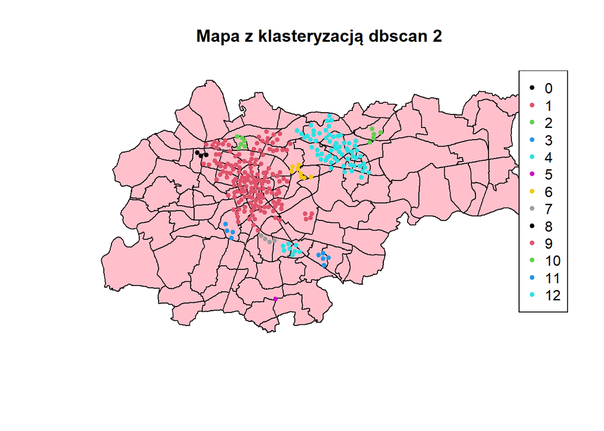

```r
#wizualizacja z klasteryzacją
plot(st_geometry(osiedla_sciezka), col = "pink", border = "black", main = "Mapa z klasteryzacją dbscan 2")
plot(st_geometry(shp_sciezka_filtered2), col = shp_sciezka_filtered2$cluster, pch = 20, add = TRUE)
legend("topright", legend = levels(shp_sciezka_filtered2$cluster),
       col = 1:length(levels(shp_sciezka_filtered2$cluster)), pch = 20)
```

Zwiększyłam odległość między dwoma punktami (eps), a także zwiększyłam minimalną liczbę punktów wymaganą do utworzenia klastra, przez co klastry w tym przypadku są większe i bardziej spójne przestrzennie. Widzimy dwie duże grupy klastrów - klaster różowy w dzielnicach: Stare Miasto, Krowodrza, Prądnik Czerwony i część Prądnika Białego, to najgęstszy klaster. A także klaster turkusowy zlokalizowany głównie w dzielnicach Mistrzejowice i Bieńczyce. Przez proces zwiększenia minimalnej liczby punktów w promieniu naszego eps, klastry które w poprzednim przykładzie był po prostu mniejszymi skupiskami punktów, w tym przypadku zostały uznane za szum. Zwiększone eps umożliwiło połączenie punktów w znacznie większe grupy, przez co możemy lepiej zidentyfikować obszary o większej intensywności zdarzeń.

## Przykład 3

```r
dbscan_dane3 <- dbscan(ramka_danych, eps= 100, minPts= 8)

#wyniki klasteryzacji dodane do danych punktowych
shp_sciezka$cluster <- as.factor(dbscan_dane3$cluster)

#usuniecie szumów, czyli tam gdzie minPts<5
shp_sciezka_filtered3 <- shp_sciezka[shp_sciezka$cluster != "0", ]

#print(shp_sciezka$cluster)
print(table(shp_sciezka_filtered3$cluster))
```

```
##
##   0   1   2   3   4   5   6   7   8   9  10  11  12  13  14  15  16  17  18  19
##   0  16  25   8  18 142  33  32  32  13  11  46  27  19  12  21  69  16  12  16
##  20  21  22  23  24  25  26  27  28  29  30  31  32  33  34  35  36  37  38  39
##  10   8  30  14   9  18  55  14   9  13  14  29  13  11  11   9  13  12  40   9
##  40  41  42  43  44  45  46  47  48  49  50  51  52  53  54  55  56  57
##   8   8  34   8   8  19   9  10  10  10   8   9   9  17  17  10  19   8
```

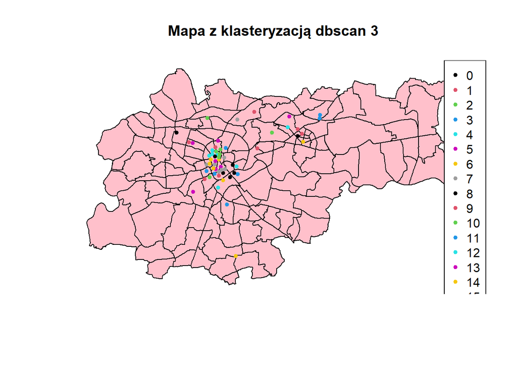

```r
#wizualizacja z klasteryzacją
plot(st_geometry(osiedla_sciezka), col = "pink", border = "black", main = "Mapa z klasteryzacją dbscan 3")
plot(st_geometry(shp_sciezka_filtered3), col = shp_sciezka_filtered3$cluster, pch = 20, add = TRUE)
legend("topright", legend = levels(shp_sciezka_filtered3$cluster),
       col = 1:length(levels(shp_sciezka_filtered3$cluster)), pch = 20)
```

# Przykłady z HDBSCAN

## Przykład 1

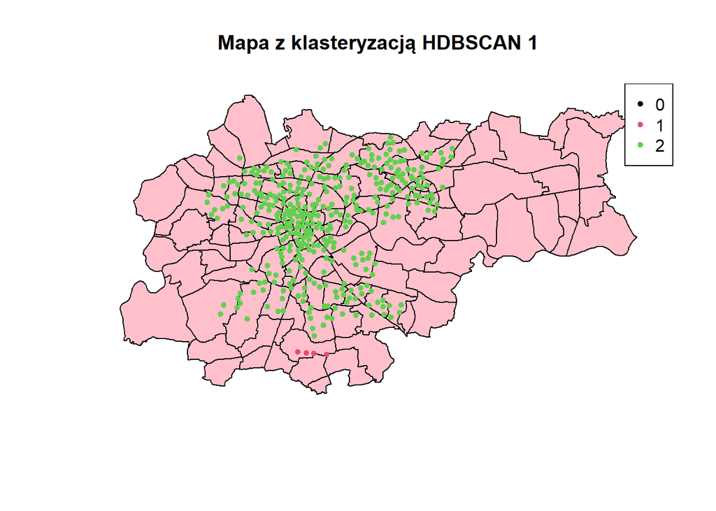

```r
hdbscan_dane1 <- hdbscan(ramka_danych, minPts = 5)
shp_sciezka$cluster_hdbscan <- as.factor(hdbscan_dane1$cluster)
shp_sciezka_filtered_hdbscan <- shp_sciezka[shp_sciezka$cluster_hdbscan != "0", ]
plot(st_geometry(osiedla_sciezka), col = "pink", border = "black", main = "Mapa z klasteryzacją HDBSCAN 1")
plot(st_geometry(shp_sciezka_filtered_hdbscan), col = shp_sciezka_filtered_hdbscan$cluster_hdbscan, pch = 20, add = TRUE)
legend("topright", legend = levels(shp_sciezka_filtered_hdbscan$cluster_hdbscan),
       col = 1:length(levels(shp_sciezka_filtered_hdbscan$cluster_hdbscan)), pch = 20)
```

## Przykład 2

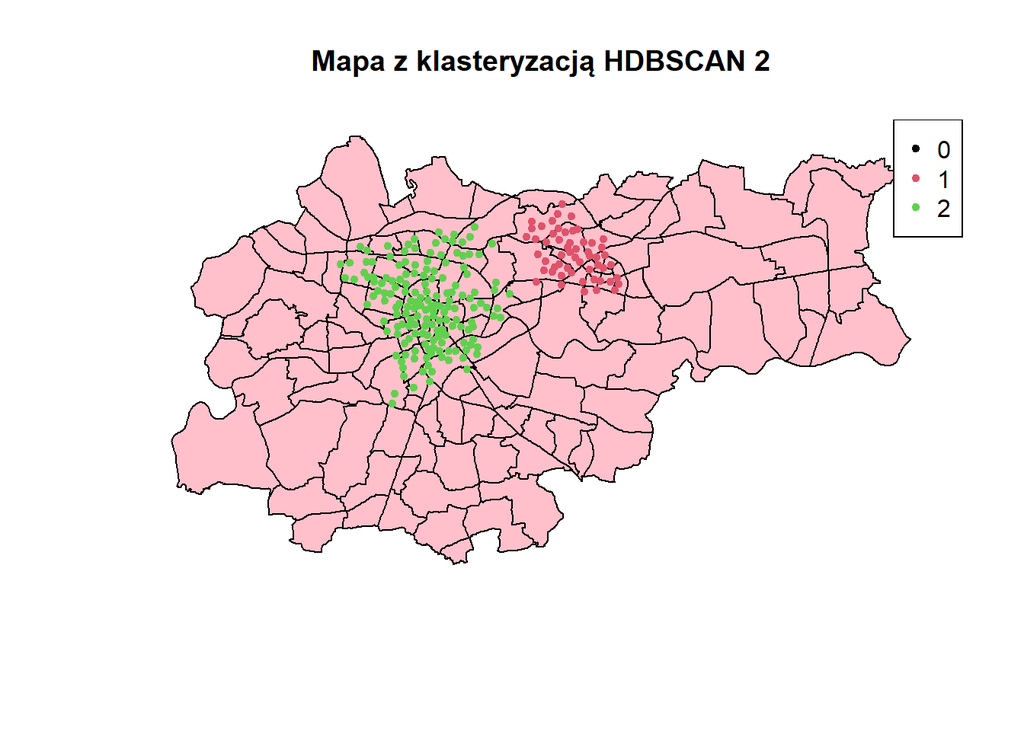

```r
hdbscan_dane2 <- hdbscan(ramka_danych, minPts = 50)
shp_sciezka$cluster_hdbscan2 <- as.factor(hdbscan_dane2$cluster)
shp_sciezka_filtered_hdbscan2 <- shp_sciezka[shp_sciezka$cluster_hdbscan2 != "0", ]
plot(st_geometry(osiedla_sciezka), col = "pink", border = "black", main = "Mapa z klasteryzacją HDBSCAN 2")
plot(st_geometry(shp_sciezka_filtered_hdbscan2), col = shp_sciezka_filtered_hdbscan2$cluster_hdbscan2, pch = 20, add = TRUE)
legend("topright", legend = levels(shp_sciezka_filtered_hdbscan2$cluster_hdbscan2),
       col = 1:length(levels(shp_sciezka_filtered_hdbscan2$cluster_hdbscan2)), pch = 20)
```

W przeciwieństwie do przykładu wyżej, mamy tutaj jasny podział na dwie grupy klastrów - zielony (klaster 2) zlokalizowany w Centrum i na północnych częściach Krakowa, a także różowy zlokalizowany w Bieńczycach, Mistrzejowicach i części Wzgórz Krzesławickich. W południowej, zachodniej i wschodniej części Krakowa nie występuje ani jeden klaster, co oznacza, że zdarzenia nie są tam aż tak częste. Wysoka wartość minPts pozwala skupić się nam na miejscach, gdzie ilość zdarzeń jest faktycznie wysoka. Można tutaj też wskazać zależność pomiędzy przepływem ruchu/ilością zabudowań a miejscem zdarzeń. Wiadomym jest, że ruch największy jest w Centrum, dlatego też gęstość zdarzeń jest tam wyraźnie największa.

## Przykład 3

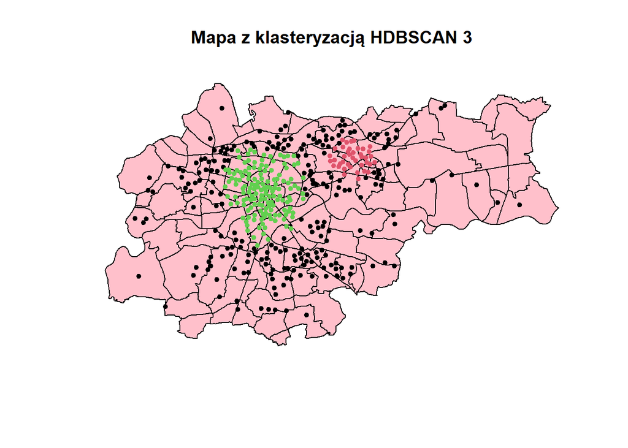

```r
hdbscan_dane3 <- hdbscan(ramka_danych, minPts = 165)
shp_sciezka$cluster_hdbscan3 <- as.factor(hdbscan_dane3$cluster)
#shp_sciezka_filtered_hdbscan2 <- shp_sciezka[shp_sciezka$cluster_hdbscan2 != "0", ]
plot(st_geometry(osiedla_sciezka), col = "pink", border = "black", main = "Mapa z klasteryzacją HDBSCAN 3")
plot(st_geometry(shp_sciezka), col = shp_sciezka$cluster_hdbscan3, pch = 20, add = TRUE)
```

W tym przykładzie dodałam też szumy, aby pokazać jak duża ilość punktów nie kwalifikuje się do naszych warunków. Bardzo duża wartość minPts=165 sprawia, że punkty klastrów są bardziej rozrzedzone względem poprzednich przykładów. Tendencja kolorystyczna, jak i występowanie klastrów innych niż szumy jest zachowana jak w przykładzie 2.

## Przykład 4

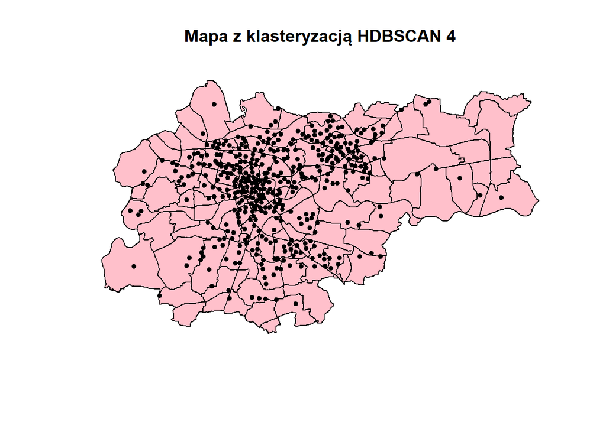

```r
hdbscan_dane4 <- hdbscan(ramka_danych, minPts = 166)
shp_sciezka$cluster_hdbscan4 <- as.factor(hdbscan_dane4$cluster)
plot(st_geometry(osiedla_sciezka), col = "pink", border = "black", main = "Mapa z klasteryzacją HDBSCAN 4")
plot(st_geometry(shp_sciezka), col = shp_sciezka$cluster_hdbscan4, pch = 20, add = TRUE)
```

Przykładem tym chciałam pokazać, że wartość minPts=165 jest ostatnią wartością dla której występują jakieś klastry. Jak widać na wizualizacji, wartość 166 jest już za duża, przez co nie mamy żadnego skupiska punktów spełniających wymagania wartości minPts.

# OPIS DBSCAN

## Zasady działania:

1. Punkty w gęstym obszarze są klastrami, a punkty w obszarach o niskiej gęstości to szumy.

### ZALETY:

1. Potrafi skutecznie zidentyfikować szumy.
2. Liczba klastrów wynika z gęstości danych, nie trzeba jej podawać.

### WADY:

1. Trudności z dopasowaniem parametrów minPts i eps - wartości te trzeba dobierać z głową, tak aby dane wynikowe były przejrzyste.

# OPIS HDBSCAN

## Zasady działania:

HDBSCAN to rozszerzenie DBSCAN, w którym parametr eps jest wybierany automatycznie. Metoda ta lepiej sobie radzi z różną gęstością danych niż DBSCAN. Mechanizm tej metody opiera się na hierarchicznej gęstości klastrów.

### ZALETY:

1. Automatyczny dobór eps - jest to ułatwienie dla użytkowników.
2. Jest bardziej dostosowany do zróżnicowanej gęstości zdarzeń.
3. Pozwala nam na analizę struktury klastrów na różnych ich poziomach szczegółowości.

### WADY:

1. Na dużych zbiorach danych metoda ta jest wolniejsza od DBSCAN.
2. Interpretacja wyników nie jest tak prosta jak w przypadku DBSCAN (moje odczucia).

# PORÓWNANIE

DBSCAN1(eps=300,minPts=5): dużo szumów, małe, dosyć lokalne klastry.

DBSCAN2(eps=500,minPts=10): mało szumów, klastry są duże i spójne.

DBSCAN3(eps=100,minPts=8): bardzo dużo szumów, klastry mamy tylko w lokalizacjach o większych gęstościach.

HDBSCAN2(minPts=50): średnia ilość szumów, występują dwa głowne podziały skupisk.

HDBSCAN3(minPts=165): duża ilość szumów, widoczne są tylko największe skupiska punktów, reszta to szumy.

HDBSCAN4(minPts=166): wszystkie punkty są szumami, wartość minPts zbyt duża.

# WNIOSKI

DBSCAN lepiej sprawdza się w przypadku danych o jednolitej gęstości. Utrudnieniem w korzystaniu z tej metody z pewnością jest dobór odpowiedniego parametru eps, co wcale nie jest takie oczywiste. HDBSCAN automatycznie dobiera eps, przez co tak naprawdę jedną rzecz (dosyć istotną) mamy z głowy. lepiej się sprawdza w przypadku zestawu danych gdzie widoczne są różnice gęstościowe. Minusem jest, że przy przypisaniu zbyt dużej wartości do parametru minPts może dać same szumy (przykład4).

# PODSUMOWANIE

W momencie gdy mamy do czynienia ze zróżnicowanymi danymi (gęstościa danych) lepiej się sprawdzi HDBSCAN, natomiast gdy nasz zestaw danych ma bardziej jednorodne dane to lepszym wyborem będzie DBSCAN.